# Semiconductor Simulation: Data Analysis Report

Tan Zen Sheen

# OBJECTIVE

To assess the significance and magnitude of the Simulated Geopolitical Intervention of the US-China Trade war on the Global Semiconductor Supply Chain Economy.

# DATA WRANGLING IN MICROSOFT EXCEL

**Step 1:** The output data from our JaamSim Semiconductor Simulation was converted from .txt file format to .xlsx file format using Microsoft Excel.

- *Past Scenario:* US is the biggest player in the semiconductor industry. China is yet to have its own capability of producing and manufacturing semiconductors and has to outsource to US & East Asia for semiconductor production and manufacturing.
- *Future Scenario:* China is capable of producing and manufacturing semiconductors on its own and has its supply chain trade links blocked from the US & East Asia.

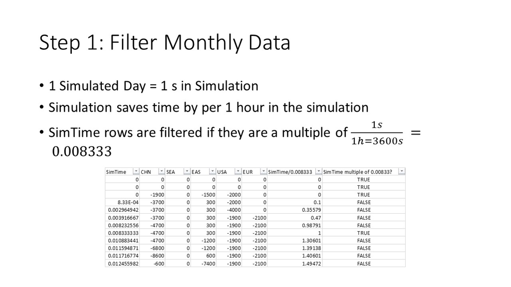

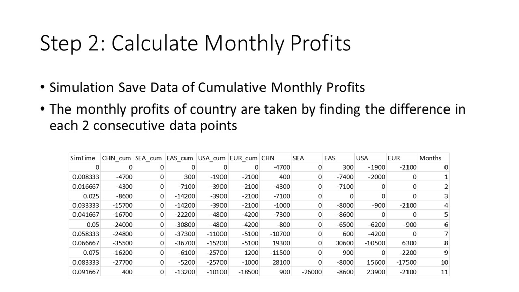

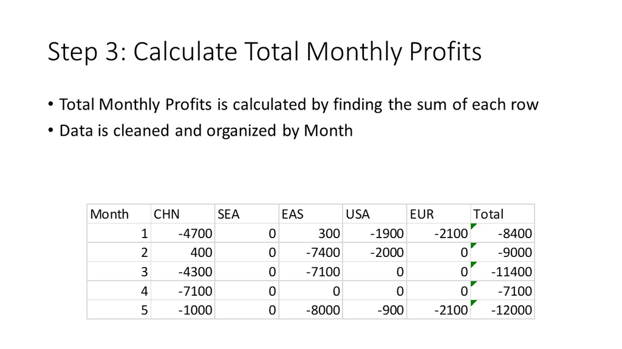

It is important to note that each observation or row in the data set represents one month in the simulation.

Both Excel files are exported as .csv files for data analysis in R.

# Exploratory Data Analysis

```r
past_ts <- read.csv('past_data.csv')
future_ts <- read.csv('future_data.csv')

# print( nrow(past_ts))
```

Let us first take a look at the total monthly profits for all 5 regions for both Past and Future Scenarios

## Look into the first few rows of the dataset to make sure it is correct

```r
show(head(past_ts))
```

```
##   Months   CHN   SEA   EAS    USA   EUR  Total
## 1      0   100   200 -3900   -600 -1200  -5400
## 2      1  -900 -5200   200  -1000     0  -6900
## 3      2   200 -2800  -800  -2000     0  -5400
## 4      3  1100 -5200   800  -3600     0  -6900
## 5      4 -2600  9500 -3600 -12000     0  -8700
## 6      5   200 -5400  2000  -7800     0 -11000
```

```r
show(head(future_ts))
```

```
##   Months   CHN   SEA   EAS   USA   EUR  Total
## 1      0 -2000 -2100 -1200   400 -1200  -6100
## 2      1 -2800 -3700     0 -1000     0  -7500
## 3      2 -7600  1800     0     0     0  -5800
## 4      3 -2200 -5100 -1200   200     0  -8300
## 5      4 -5400 -3700  -900     0     0 -10000
## 6      5 -9400  2000  1000 -5800     0 -12200
```

## Visualize Total Monthly Profits

Due to the large number of observations, we will visaulize the first 400 observations in the data.

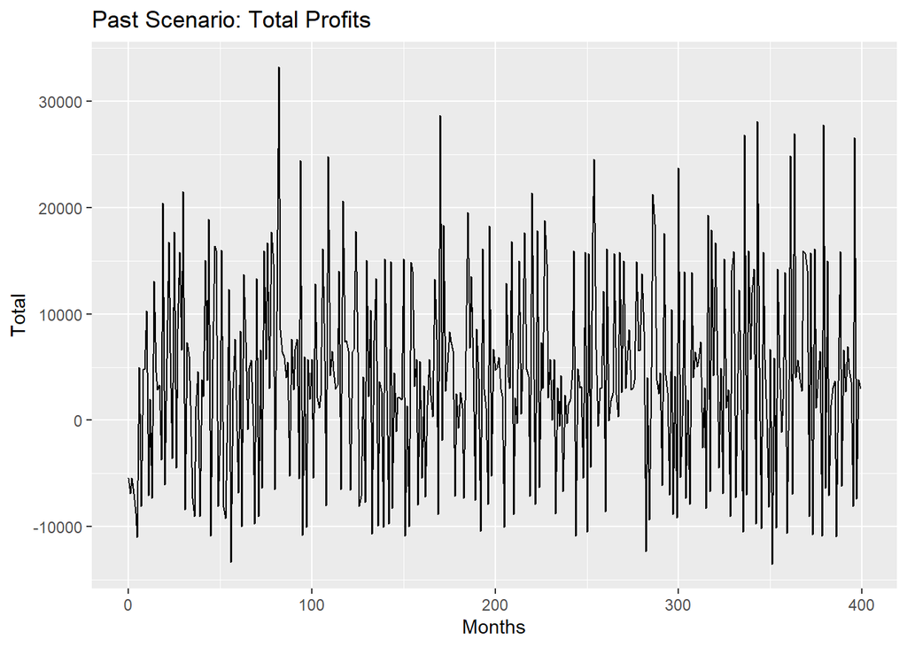

```r
library(ggplot2)

## Visualize Total Profits for Past scenarios:
ggplot(past_ts[1:400,], aes(x = Months, y = Total)) + geom_line(color="black") + ggtitle("Past Scenario: Total Profits")
```

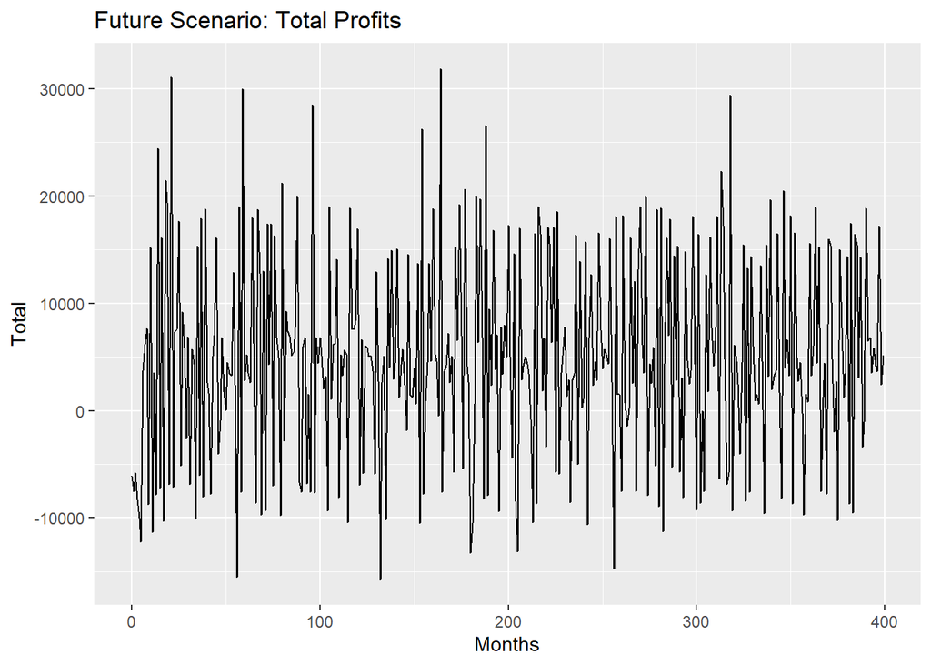

```r
## Visualize Total Profits for Future scenarios:
ggplot(future_ts[1:400,], aes(x = Months, y = Total)) + geom_line(color="black") + ggtitle("Future Scenario: Total Profits")
```

## Compute means and variances of Monthly Profits of all regions in both Past and Future Scenarios

```r
past_means <- colMeans(past_ts[2:7])
past_variances <- apply(past_ts[2:7], 2, var)

# Create a new dataframe to store the results
summary_past <- data.frame(
  # Series = colnames(past_ts),
  Mean = past_means,
  Variance = past_variances
)

# Display the summary dataframe
show(summary_past)
```

```
##            Mean Variance
## CHN    691.4934 32024964
## SEA    779.7485 47016498
## EAS   1268.1516 31098294
## USA   1522.1008 69745182
## EUR    106.9368  7114490
## Total 4368.4310 92736607
```

```r
future_means <- colMeans(future_ts[2:7])
future_variances <- apply(future_ts[2:7], 2, var)

# Create a new dataframe to store the results
summary_future <- data.frame(
  # Series = colnames(past_ts),
  Mean = future_means,
  Variance = future_variances
)

# Display the summary dataframe
show(summary_future)
```

```
##            Mean Variance
## CHN   2337.6839 40671512
## SEA   1453.4643 34092202
## EAS    110.3394  8882282
## USA    697.6412 33163002
## EUR    111.7202  7894731
## Total 4710.8490 99646913
```

## Problems with Data

- **There is an initialization bias**
- **Data has a lot of fluctuations and has a very high variances, making it difficult for us to get any meaningful results with hypothesis testing**

# Remove Initalization Bias

As running multiple simulations from JaamSim is difficult, we have to make do with the time series data from 1 simulation only. Hence, we are not able to use Welch’s method to find the average of k simulations. Rather we can instead gauge the initialization bias by observing the initialization bias of the current data set, then setting the burn-in period to be 2 times the observed burn-in period, so we can be sure that all initialization bias is removed.

Also, we will visualize the monthly profits of all regions in both past and future data sets, and take the burn-in period of the region and time period that has the longest initialization bias.

## Past Scenario - Visualize Monthly Profit of each region to determine burn-in period

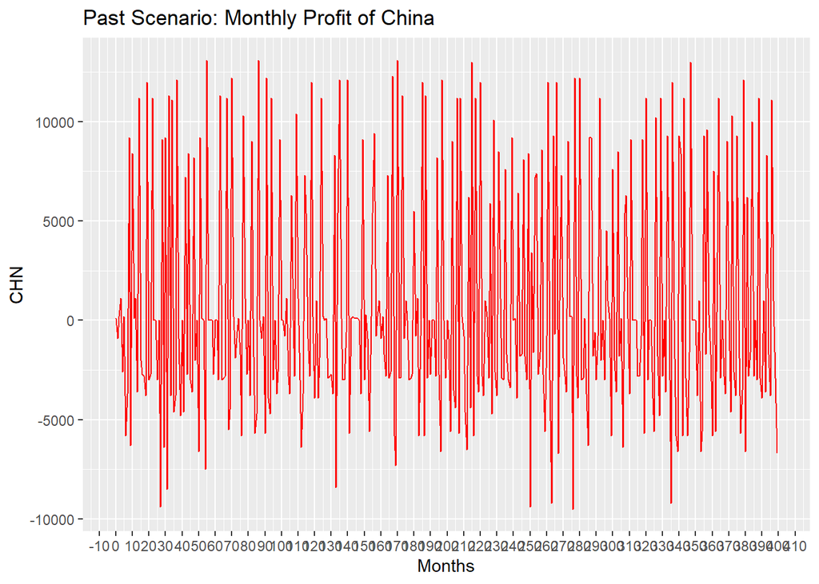

```r
ggplot(past_ts[1:400,], aes(x = Months, y = CHN)) + geom_line(color="red") + ggtitle("Past Scenario: Monthly Profit of China")+
    scale_x_continuous(n.breaks= 40 )
```

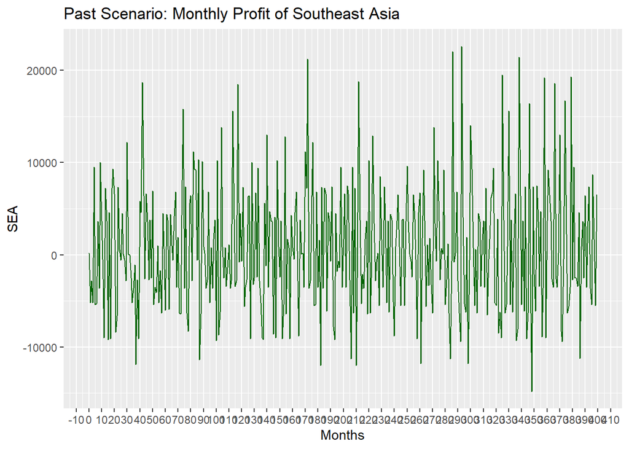

```r
ggplot(past_ts[1:400,], aes(x = Months, y = SEA)) + geom_line(color="dark green") + ggtitle("Past Scenario: Monthly Profit of Southeast Asia")+
    scale_x_continuous(n.breaks= 40 )
```

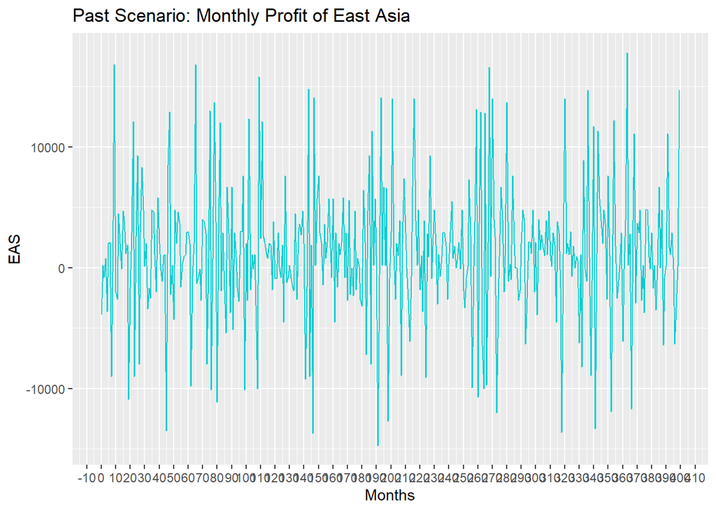

```r
ggplot(past_ts[1:400,], aes(x = Months, y = EAS)) + geom_line(color="dark turquoise") + ggtitle("Past Scenario: Monthly Profit of East Asia")+
    scale_x_continuous(n.breaks= 40 )
```

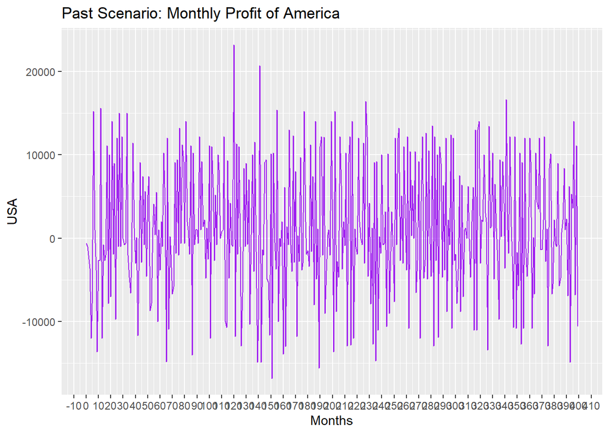

```r
ggplot(past_ts[1:400,], aes(x = Months, y = USA)) + geom_line(color="purple") + ggtitle("Past Scenario: Monthly Profit of America")+
    scale_x_continuous(n.breaks= 40 )
```

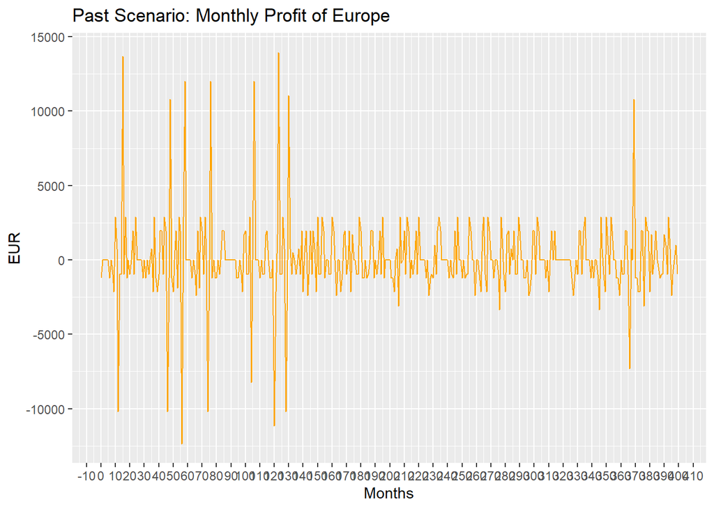

```r
ggplot(past_ts[1:400,], aes(x = Months, y = EUR)) + geom_line(color="orange") + ggtitle("Past Scenario: Monthly Profit of Europe")+
    scale_x_continuous(n.breaks= 40 )
```

Looking at the past data, the burn-in period for most of the countries is about 10 months.

## Future Scenario - Visualize Monthly Profit of each region to determine burn-in period

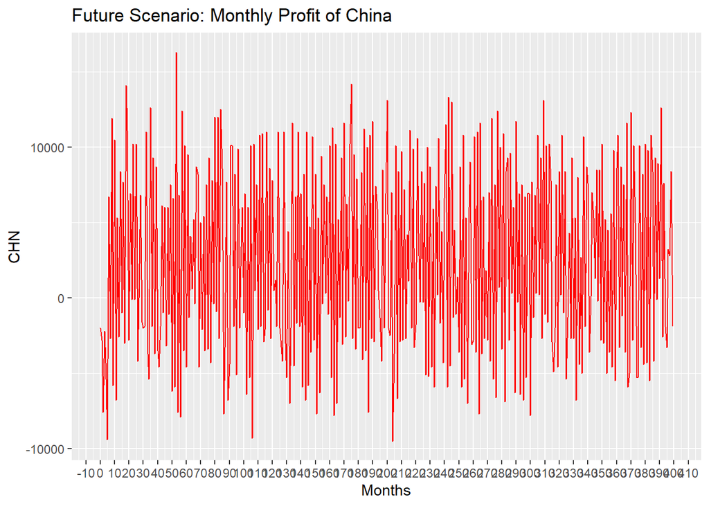

```r
ggplot(future_ts[1:400,], aes(x = Months, y = CHN)) + geom_line(color="red") + ggtitle("Future Scenario: Monthly Profit of China")+
    scale_x_continuous(n.breaks= 40 )
```

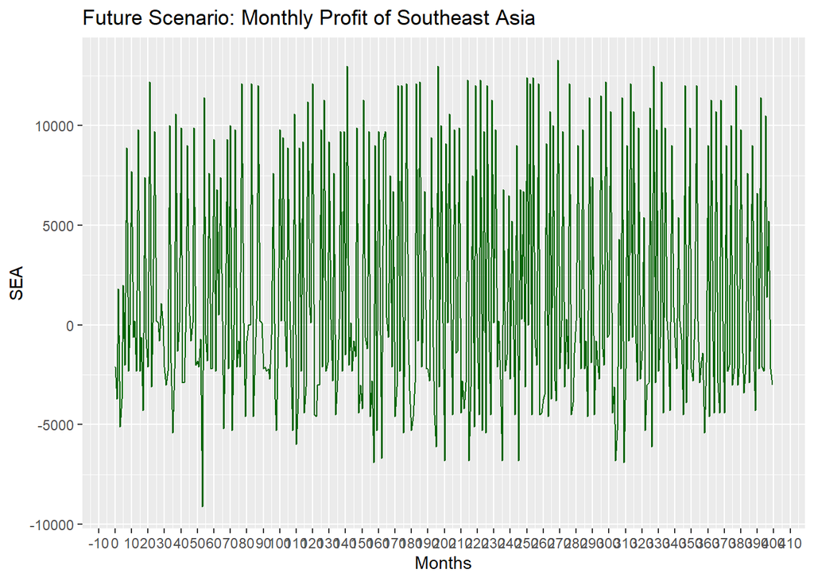

```r
ggplot(future_ts[1:400,], aes(x = Months, y = SEA)) + geom_line(color="dark green") + ggtitle("Future Scenario: Monthly Profit of Southeast Asia")+
    scale_x_continuous(n.breaks= 40 )
```

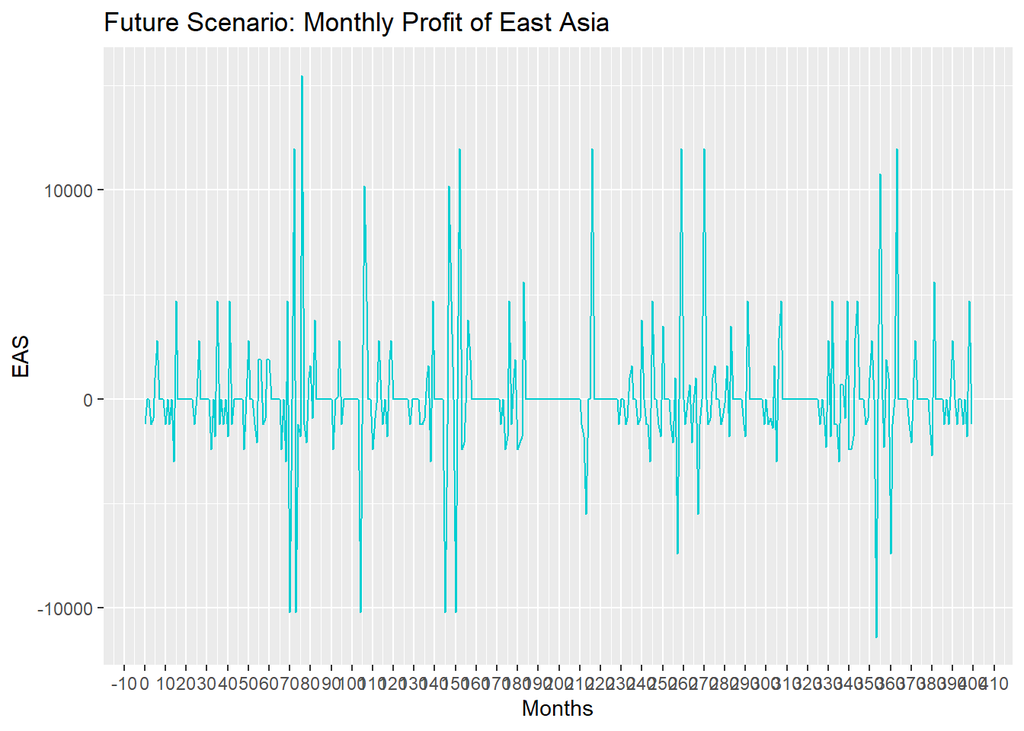

```r
ggplot(future_ts[1:400,], aes(x = Months, y = EAS)) + geom_line(color="dark turquoise") + ggtitle("Future Scenario: Monthly Profit of East Asia")+
    scale_x_continuous(n.breaks= 40 )
```

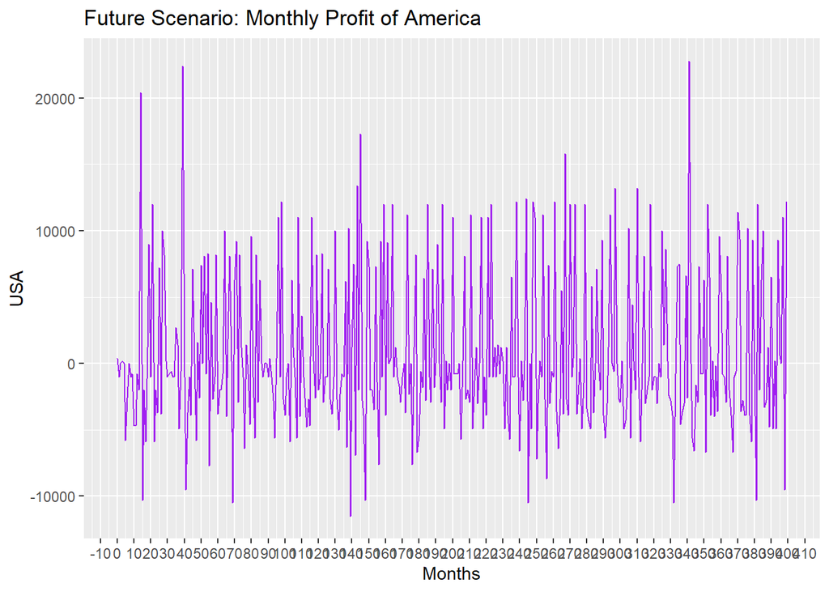

```r
ggplot(future_ts[1:400,], aes(x = Months, y = USA)) + geom_line(color="purple") + ggtitle("Future Scenario: Monthly Profit of America")+
    scale_x_continuous(n.breaks= 40 )
```

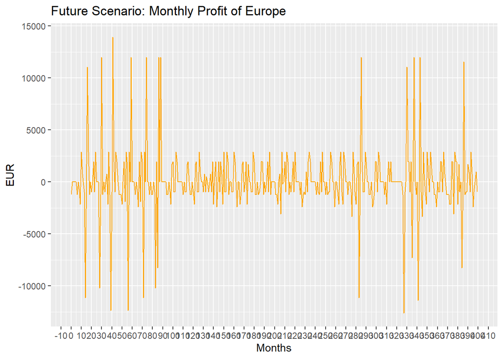

```r
ggplot(future_ts[1:400,], aes(x = Months, y = EUR)) + geom_line(color="orange") + ggtitle("Future Scenario: Monthly Profit of Europe")+
    scale_x_continuous(n.breaks= 40 )
```

Looking at the future data, all countries have a burn-in period of about 10 months.

With this, we conclude that the burn-in period of the data is 10 months for the both past and present data.

Setting the burn-in period as the maximum burn-in period in the data (10 months) and then multiplying by 2, **we get a burn-in period of 20 months for both past and future data sets**. So the first 20 observations of the data is removed.

## Removed burn-in period of first 20 observations

```r
new_past_ts <- past_ts[ 21:nrow(past_ts) , 1:7 ]
new_future_ts <- future_ts[ 21:nrow(future_ts) , 1:7 ]
print(nrow( new_past_ts ) )
```

```
## [1] 12147
```

```r
print(nrow(new_future_ts))
```

```
## [1] 12147
```

It is notable that we are now left with 12147 observations from both past and future data sets respectively. Now that the burn-in period has been removed, we are confident that there is no more initialization bias.

# Batch Means Approach

In reducing the variance of both past and future data sets, we will use the Batch Means Approach to analyze both Time Series data sets.

We split up the time series data into 1000 batches of 12 data points. As each data point represents 1 month, each batch will represent 1 year in the simulation. By applying a Batch Means approach to analyze the Time Series data, we are essentially analyzing the average monthly profits of each year in the Simulation.

By treating each year as an independent simulation, we compute 2 samples of average monthly profits of each year for both Past and Future simulations.

We then compute the means and variances of the samples to get a good estimate of the means and variances of the monthly profits of each year,

To simplify the process of splitting up the time series into batches, we subset 12000 of the observations, and split them into 1000 batches of 12 observations.

```r
# Helper function to do batch means approach
batch_mean_approach <- function(input_data) {
  # Subset the first 600 observations
  subset_data <- input_data[1:12000]

  # Split into 20 batches of 600 observations
  batches <- split(subset_data, rep(1:1000, each = 12))

  # Calculate the average monthly profit of the 20 batches
  batch_mean <- sapply(batches, mean)

  return(batch_mean)
}

batch_mean_future <- data.frame( lapply(new_future_ts, batch_mean_approach) )
batch_mean_future<- batch_mean_future[ 2:7 ]
batch_mean_past <- data.frame( lapply(new_past_ts, batch_mean_approach) )
batch_mean_past <- batch_mean_past[2:7]
# future_chn_ATH <- antithetic_variable( future_ts$CHN )
```

We now have 1000 rows of batch mean monthly profits for each Past and Future Data Sets.

```r
print( head(batch_mean_past) )
```

```
##         CHN       SEA       EAS       USA        EUR    Total
## 1 -291.6667 1033.3333 2191.6667 3400.0000  45.833333 6379.167
## 2 1375.0000  -50.0000  733.3333 -316.6667 -66.666667 1675.000
## 3 1358.3333 -341.6667 1350.0000 1275.0000 483.333333 4125.000
## 4  675.0000  208.3333 1366.6667 -450.0000  -4.166667 1795.833
## 5   75.0000  616.6667 1825.0000 2791.6667 358.333333 5666.667
## 6 1150.0000 3033.3333  416.6667 1866.6667 145.833333 6612.500
```

```r
print( nrow(batch_mean_past) )
```

```
## [1] 1000
```

```r
print( head(batch_mean_future ))
```

```
##        CHN      SEA       EAS       USA        EUR    Total
## 1 1783.333 1025.000 141.66667 1616.6667 195.833333 4762.500
## 2 1916.667 1050.000 -16.66667  266.6667  83.333333 3300.000
## 3 2016.667 1208.333 -75.00000  975.0000 333.333333 4458.333
## 4 2741.667 1508.333 100.00000 1366.6667  -4.166667 5712.500
## 5 2075.000 2016.667 291.66667   25.0000 358.333333 4766.667
## 6 3091.667 1200.000 175.00000 1083.3333 445.833333 5995.833
```

```r
print( nrow(batch_mean_future ))
```

```
## [1] 1000
```

## Compute Means and Variances of new Past and Future data

```r
past_batch_means <- colMeans(batch_mean_past)
past_batch_variances <- apply(batch_mean_past, 2, var)

# Create a new dataframe to store the results
summary_batch_past <- data.frame(
  # Series = colnames(past_ts),
  Mean = past_batch_means,
  Variance = past_batch_variances
)

show(summary_batch_past)
```

```
##            Mean  Variance
## CHN    693.0333  295940.5
## SEA    781.3167  936075.1
## EAS   1270.6500  650809.4
## USA   1521.2000 2092837.3
## EUR    107.3458  151786.9
## Total 4373.5458 3008253.7
```

```r
future_batch_means <- colMeans(batch_mean_future)
future_batch_variances <- apply(batch_mean_future, 2, var)

# Create a new dataframe to store the results
summary_batch_future <- data.frame(
  # Series = colnames(past_ts),
  Mean = future_batch_means,
  Variance = future_batch_variances
)

show(summary_batch_future)
```

```
##            Mean  Variance
## CHN   2340.1833  964808.7
## SEA   1458.2750  769184.8
## EAS    110.5583  135772.1
## USA    699.2500  721438.1
## EUR    113.4958  157563.5
## Total 4721.7625 2565312.7
```

## Variance Reduction

Let us see how much was the variance reduced through the Batch Means Approach.

```r
show( summary_batch_past - summary_past )
```

```
##             Mean  Variance
## CHN    1.5399496 -31729023
## SEA    1.5681666 -46080423
## EAS    2.4984425 -30447485
## USA   -0.9007644 -67652345
## EUR    0.4090371  -6962703
## Total  5.1148314 -89728353
```

```r
show( summary_batch_future - summary_future )
```

```
##             Mean  Variance
## CHN    2.4994343 -39706703
## SEA    4.8107114 -33323017
## EAS    0.2188906  -8746510
## USA    1.6088395 -32441564
## EUR    1.7756065  -7737167
## Total 10.9134822 -97081600
```

It can be seen that that there has been slight changes to the mean, while the variance has reduced significantly.

Side note: The change in mean is due to the removal of the initialization bias, and the rounding off error in the computation of the batch means.

# 2 Sample T-tests for all regions and Total

In order to determine if the past and future average monthly profits are statistically different, we treat the batch means of both past and future monthly profits across all 5 regions as 2 different samples, and construct a 2 sample T-test for each region.

$$\\ Let \ \mu_{1i} \ represent \ the \
past \ mean \ monthly \ profits \ of \ the \ i^{th} \ region \\
and \ \mu_{2i} \ represent \ the \ future \ mean \ monthly \ profits \
of \ the \ i^{th} \ region \\
\\ Constructing \ the \ Hypothesis \ test \ for \ each \ region \ i :
\\H_0: \mu_{1i} - \mu_{2i} = 0
\\H_1: \mu_{1i} - \mu_{2i} \ne 0$$

```r
# Helper function for the 2 Sample T-tests.
t_test <- function ( population1 , population2 ){
  # Calculate sample statistics
  mean1 <- mean(population1)
  mean2 <- mean(population2)
  var1 <- var(population1)
  var2 <- var(population2)
  n1 <- length(population1)
  n2 <- length(population2)

  # Calculate the standard error of the difference
  SE <- sqrt((var1 / n1) + (var2 / n2))

  # Calculate the t-value
  t_value <- (mean1 - mean2) / SE

  # Calculate degrees of freedom
  df <- (var1 / n1 + var2 / n2)^2 / ((var1^2 / (n1^2 * (n1 - 1))) + (var2^2 / (n2^2 * (n2 - 1))))

  # Calculate the p-value
  p_value <- 2 * pt(-abs(t_value), df)

  # Calculate the confidence interval
  margin_of_error <- qt(0.975, df) * SE #2.5th percentile for two-tailed test
  confidence_interval <- c( round(mean1 - mean2 - margin_of_error,3) , round(mean1 - mean2 + margin_of_error,3) )

  # Display the results
  print(paste("t-value:", round( t_value,3) ) )
  # print(paste("Degrees of Freedom:", df))
  print(paste("p-value:", round(p_value,5) ))
  print(paste("95% Confidence Interval:", "(", confidence_interval[1], ",", confidence_interval[2], ")"))

}
```

## T-test for China

```r
CHN_t_test <- t_test( batch_mean_past$CHN , batch_mean_future$CHN)
```

```
## [1] "t-value: -46.389"
## [1] "p-value: 0"
## [1] "95% Confidence Interval: ( -1716.797 , -1577.503 )"
```

With a negative t value of -46.389, and the 95% confidence interval of ( -1716.797 , -1577.503 ) that does not contain 0, we reject the null hypothesis and show that the mean monthly profits of China in the future is significantly higher than in the past.

## T-test for Southeast Asia

```r
SEA_t_test <- t_test( batch_mean_past$SEA , batch_mean_future$SEA)
```

```
## [1] "t-value: -16.393"
## [1] "p-value: 0"
## [1] "95% Confidence Interval: ( -757.944 , -595.972 )"
```

## T-test for East Asia

```r
EAS_t_test <- t_test( batch_mean_past$EAS , batch_mean_future$EAS)
```

```
## [1] "t-value: 41.364"
## [1] "p-value: 0"
## [1] "95% Confidence Interval: ( 1105.075 , 1215.109 )"
```

With a positive t value of 41.364, and the 95% confidence interval of ( 1105.075 , 1215.109 ) that does not contain 0, we reject the null hypothesis and show that the mean monthly profits of East Asia in the future is significantly lower than in the past.

## T-test for United States of America

```r
USA_t_test <- t_test( batch_mean_past$USA , batch_mean_future$USA)
```

```
## [1] "t-value: 15.494"
## [1] "p-value: 0"
## [1] "95% Confidence Interval: ( 717.896 , 926.004 )"
```

With a positive t value of 15.494, and the 95% confidence interval of ( 717.896 , 926.004 ) that does not contain 0, we reject the null hypothesis and show that the mean monthly profits of America in the future is significantly lower than in the past.

## T-test for Europe

```r
EUR_t_test <- t_test( batch_mean_past$EUR , batch_mean_future$EUR)
```

```
## [1] "t-value: -0.35"
## [1] "p-value: 0.72663"
## [1] "95% Confidence Interval: ( -40.643 , 28.343 )"
```

## T-test for Total Monthly Profits across all 5 Regions

```r
TOTAL_t_test <- t_test( batch_mean_past$Total , batch_mean_future$Total)
```

```
## [1] "t-value: -4.664"
## [1] "p-value: 0"
## [1] "95% Confidence Interval: ( -494.63 , -201.804 )"
```

With a negative t value of -4.664, and the 95% confidence interval of ( -494.63 , -201.804 ), we reject the null hypothesis and show that the mean total monthly profits of all 5 regions in the future is significantly higher than in the past.

## Through the Hypothesis Testing, we arrive at the conclusion that China, Southest Asia, East Asia and United States have been impacted with significant losses/gains.

Now, let us see how much profit/loss did each region get after the Geopolitical Intervention.

## Percentage Change in profits

```r
percentage_change <- paste( ( round(
  ( colMeans( new_future_ts[2:7] ) - colMeans(new_past_ts[2:7])  )/ colMeans(new_past_ts[2:7]) * 100
  , 2)  ) , "%" )
percentage_change <- cbind( colnames( new_future_ts[2:7] ) , percentage_change )
print( percentage_change )
```

```
##              percentage_change
## [1,] "CHN"   "238.15 %"
## [2,] "SEA"   "86.35 %"
## [3,] "EAS"   "-91.29 %"
## [4,] "USA"   "-54.16 %"
## [5,] "EUR"   "4.47 %"
## [6,] "Total" "7.8 %"
```

Looking at the Percentage Change, the Regions that profited through the Geopolitical Intervention are China and Southeast Asia, while the regions that suffered losses are East Asia and the United States of America. Refer to the report for a detailed explanation on the various percentage changes of each region.

# Conclusion

In this analysis, we used a Batch Means Approach to analyze the monthly profits of the data and conducted 2 Sample T-tests to determine if there is a significant difference between both past and future datasets. After the tests, we arrived at the conclusion that the United States and East Asia suffered significant losses in the Semiconductor Supply Chain, while China and Southeast Asia had a significant increase in profits.